# Reproducible Research project 1

Roderic Reckley

February 7, 2016

## Loading and preprocessing the data

The first step is to include the necessary libraries and identify the location of the data file to be read in. The data is read in via the read.csv function.

```r
library(ggplot2)
library(lattice)
setwd("C:/Users/RNRECKLEY/Downloads/coursera/datascience/reproducible/project1")
activity_data <- read.csv("activity.csv")
activity_data$date <- as.Date(activity_data$date)
```

```
## [1] "The total number of observations found in the activity data set is :  17568"
```

## What is mean total number of steps taken per day?

The first step is to remove the observations with the missing values from the data set. Once this is done generate the histogram using the ggplot function.

```r
cleaned_data <- na.omit(activity_data)
```

```
## [1] "The number of observations left in the  activity data set after removing those with missing values is :  15264"
```

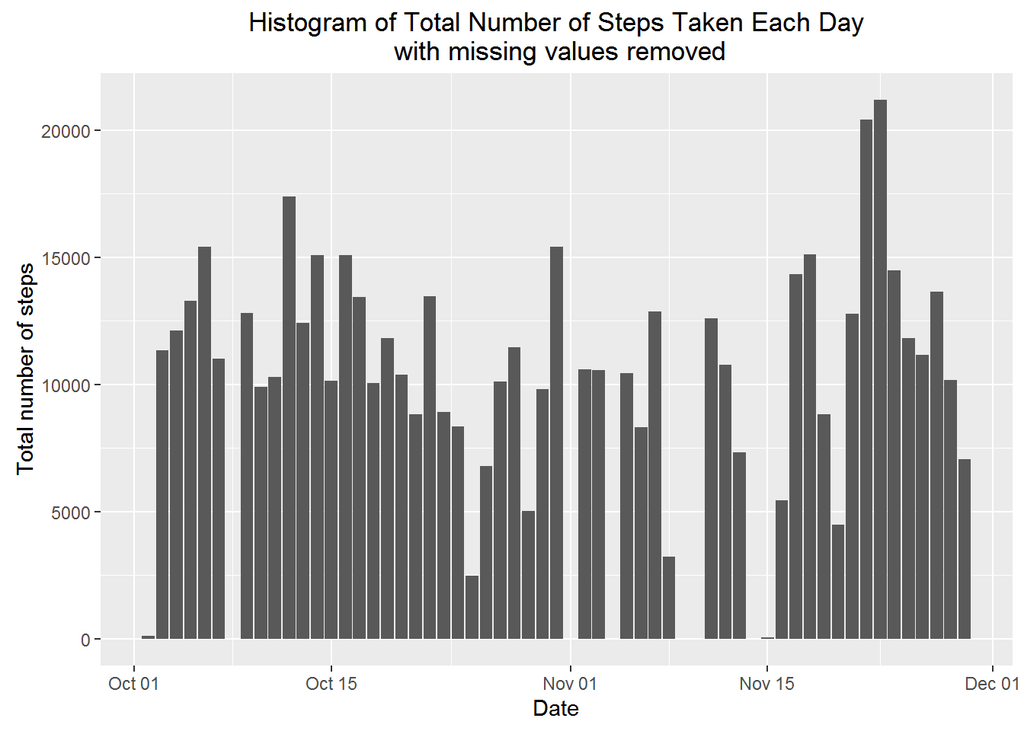

```r
sum_data <- aggregate(activity_data$steps, by=list(activity_data$date), FUN=sum, na.rm=TRUE)
names(sum_data) <- c("Date", "TotalSteps")
```

#### Find the mean and medial values of the activity data set.

```
## [1] "The mean number of steps taken per day with missing data is  9354"
```

```
## [1] "The median number of steps taken per with the missing data is  10395"
```

```r
cleaned_sum_data <- aggregate(cleaned_data$steps, by=list(cleaned_data$date), FUN=sum, na.rm=TRUE)
names(cleaned_sum_data) <- c("Date", "TotalSteps")
```

```
## [1] "The mean number of steps taken per day without the missing data is  10766"
```

```
## [1] "The median number of steps taken per without the missing data is  10765"
```

## What is the average daily activity pattern?

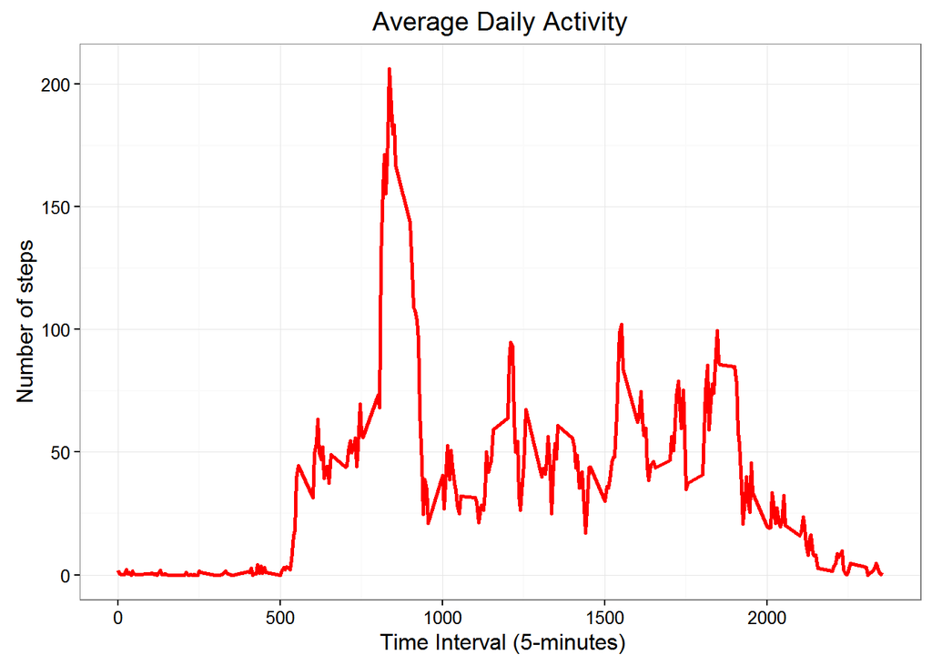

```r
avg_daily <- aggregate(cleaned_data$steps, list(interval = as.numeric(as.character(cleaned_data$interval))), FUN = "mean")
names(avg_daily)[2] <- "AverageSteps"
```

Which 5-minute interval, on average across all the days in the dataset, contains the maximum number of steps?

```r
max_interval <- avg_daily[which.max(avg_daily$AverageSteps),]
print(max_interval)
```

```
##     interval AverageSteps
## 104      835     206.1698
```

The maximum number of steps observed across all days occurs at interval 835 with an average of 206.1698 steps.

## Imputing missing values

```
## [1] "The total number of missing values in the activity data set is  2304"
```

```r
sum(is.na(activity_data))
```

```
## [1] 2304
```

```r
imputed_activity <- merge(activity_data, avg_daily, by="interval")
missing_values <- which(is.na(imputed_activity$steps))
imputed_activity$steps[missing_values] <- imputed_activity$AverageSteps[missing_values]
imputed_activity <- imputed_activity[,c(1:3)]
sum(is.na(imputed_activity))
```

```
## [1] 0
```

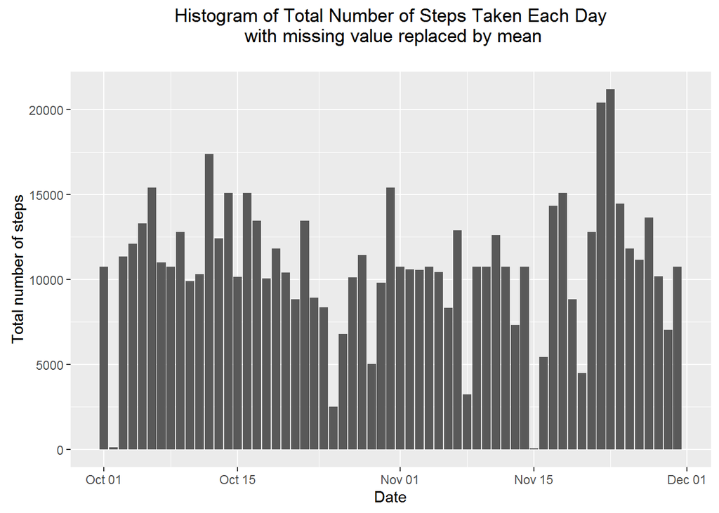

```r
imputed_steps_taken <- aggregate(imputed_activity$steps, by=list(imputed_activity$date), FUN=sum)
names(imputed_steps_taken) <- c("Date", "TotalSteps")
```

#### Find the mean and medial values of the activity data after imputing the missing data.

```
## [1] "The mean number of steps taken per day after imputing the missing data is  10766"
```

```
## [1] "The median number of steps taken per day after imputing the missing data is  10766"
```

#### What is the impact of imputing missing data on the estimates of the total daily number of steps?

If the observations with missing data are included when calculating the mean and median, imputing the data has a significant impact on the calculation of the mean and median. In this instance, the mean increases from 9354 to 10766. The median increases from 10395 to 10766.

If the observations with missing data are excluded from calculating the mean and median, imputing the data has no impact. The mean and median generated approximately the same.

## Are there differences in activity patterns between weekdays and weekends?

```r
imputed_activity$Day <- factor(format(imputed_activity$date, "%A"))
levels(imputed_activity$Day)
```

```
## [1] "Friday"    "Monday"    "Saturday"  "Sunday"    "Thursday"  "Tuesday"
## [7] "Wednesday"
```

```r
levels(imputed_activity$Day) <- list(weekday = c("Monday", "Tuesday","Wednesday","Thursday", "Friday"),
                                 weekend = c("Saturday", "Sunday"))
levels(imputed_activity$Day)
```

```
## [1] "weekday" "weekend"
```

```r
table(imputed_activity$Day)
```

```
##
## weekday weekend
##   12960    4608
```

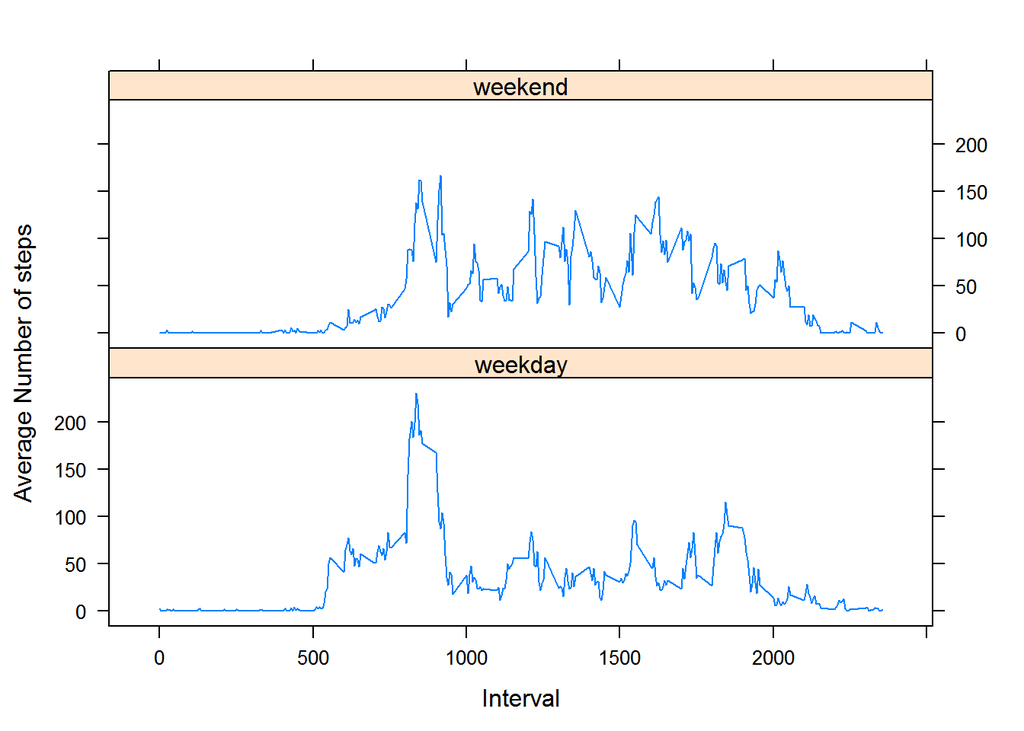

```r
steps_taken_by_day <- aggregate(imputed_activity$steps,
                                list(interval= as.numeric(as.character(imputed_activity$interval)),
                                     weekdays = imputed_activity$Day), FUN = "mean")

names(steps_taken_by_day)[3] <- "AvgSteps"
```

When examining the graph of the weekend and weekday activity, several distinct patterns emerge. First, the weekdays has the peak or largest average number of steps is observed. Here the peak occurs during the morning and drops off significantly during the middle of the day. Minor peaks of activity are observed during the early afternoon and evening hours of a weekday. With the weekend, the activity peak occurs during the same interval, but the average number of steps observed during this period is less. Unlike weekday’s, there is more activity observed after the initial peak. The weekend activity appears to spread out during the majority of the day.